# Project C7

J.G

2025-12-26

## Executive Summary

Using a sample of 32 automobiles, we tried to respond to questions about if there is a difference in the miles per gallon consumption due to the type of automobile transmission and if is it possible to quantify it. The Exploratory Data Analysis was done via boxplots where it can be inferred that there is a significant difference which was tested using the two sample $t$-test. Several Linear Regression Models were fitted in order to quantify that difference: even though the Simple Linear Regression Model provide a regression coefficient to measure that difference, the model assumptions are violated. Other Multiple Regression Models were fitted and some variables were dropped using the Variance Inflance Factor as a measure to drop out variables from the model.

## Report

The data is a data frame containing 10 aspects of automobile design and performance for 32 automobiles (73-74 models). The variable `am` is a binary variable standing for the transmission type: $0$ for automatic and $1$ for manual. The variable `mpg` is the miles per gallon fuel consumption.

Let’s take a look at the data.

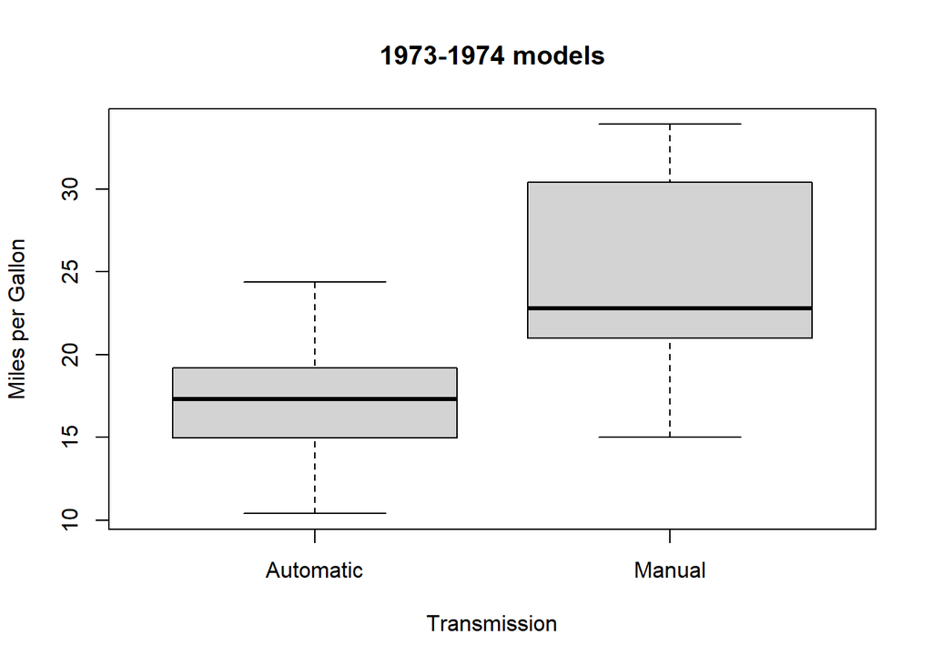

```r
boxplot(mpg ~ am, data = mtcars, main = "1973-1974 models", xlab = "Transmission", names = c("Automatic", "Manual"), ylab = "Miles per Gallon")
```

```r
with(mtcars, tapply(mpg, am, summary))
```

```
## $`0`
##    Min. 1st Qu.  Median    Mean 3rd Qu.    Max.
##   10.40   14.95   17.30   17.15   19.20   24.40
##
## $`1`
##    Min. 1st Qu.  Median    Mean 3rd Qu.    Max.
##   15.00   21.00   22.80   24.39   30.40   33.90
```

```r
## Statistical Inference: difference in mean
mpg_auto <- mtcars$mpg[mtcars$am==0]
mpg_manual <- mtcars$mpg[mtcars$am==1]

## Test if the mean level of the mpg is greater for auto than for manual automobiles, so the alternative is "less".
t.test(mpg_auto, mpg_manual, paired = FALSE, alternative = "less")
```

```
##
##  Welch Two Sample t-test
##
## data:  mpg_auto and mpg_manual
## t = -3.7671, df = 18.332, p-value = 0.0006868
## alternative hypothesis: true difference in means is less than 0
## 95 percent confidence interval:
##       -Inf -3.913256
## sample estimates:
## mean of x mean of y
##  17.14737  24.39231
```

```r
## Check for normality assumption
library(nortest)
ad.test(mpg_auto)
```

```
##
##  Anderson-Darling normality test
##
## data:  mpg_auto
## A = 0.17192, p-value = 0.9166
```

```r
ad.test(mpg_manual)
```

```
##
##  Anderson-Darling normality test
##
## data:  mpg_manual
## A = 0.30016, p-value = 0.5298
```

Since the $p-$value of the two sample t-test is $p = 0.0006 < \alpha = 0.05$ we reject the null hypothesis and conclude in favour of the alternative: $\mu_{auto} < \mu_{manual}$ at the $95\%$ level. The normality assumption was tested using the Anderson-Darling test, and we fail to reject the normality assumption.

## Linear models

We can fitt a regression model using only two variables

```r
model1 <- lm(mpg ~ am, data = mtcars)
summary(model1)
```

```
##
## Call:
## lm(formula = mpg ~ am, data = mtcars)
##
## Residuals:
##     Min      1Q  Median      3Q     Max
## -9.3923 -3.0923 -0.2974  3.2439  9.5077
##
## Coefficients:
##             Estimate Std. Error t value Pr(>|t|)
## (Intercept)   17.147      1.125  15.247 1.13e-15 ***
## am             7.245      1.764   4.106 0.000285 ***
## ---
## Signif. codes:  0 '***' 0.001 '**' 0.01 '*' 0.05 '.' 0.1 ' ' 1
##
## Residual standard error: 4.902 on 30 degrees of freedom
## Multiple R-squared:  0.3598, Adjusted R-squared:  0.3385
## F-statistic: 16.86 on 1 and 30 DF,  p-value: 0.000285
```

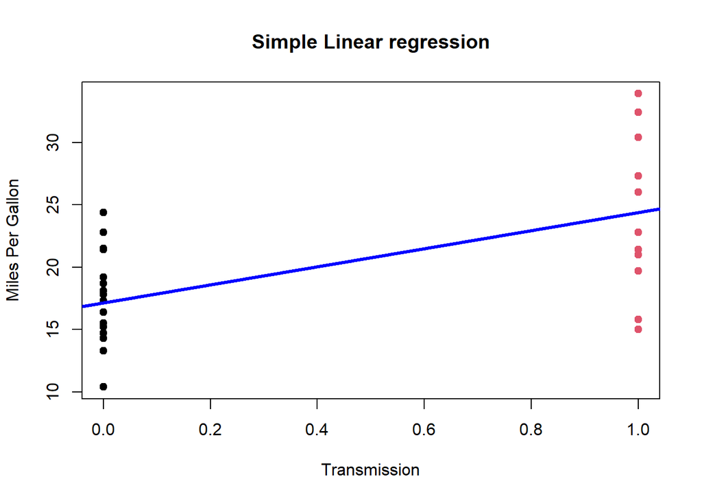

```r
plot(mtcars$am,mtcars$mpg, pch = 19,col = factor(mtcars$am), main = "Simple Linear regression", ylab = "Miles Per Gallon", xlab = "Transmission")
abline(lm(mpg ~ am, data = mtcars), col = "blue", lwd = 3)
```

As the coefficients are $\beta_0 = 17.147$ and $\beta_1 = 7.245$, that means that there is a mean difference of 7.245 mpg between automatic (17.147 estimated mean mpg, the reference level) and manual transmission (24.392 estimated mean mpg).

## Residual analysis.

Let’s make a diagnosis of this SLR model.

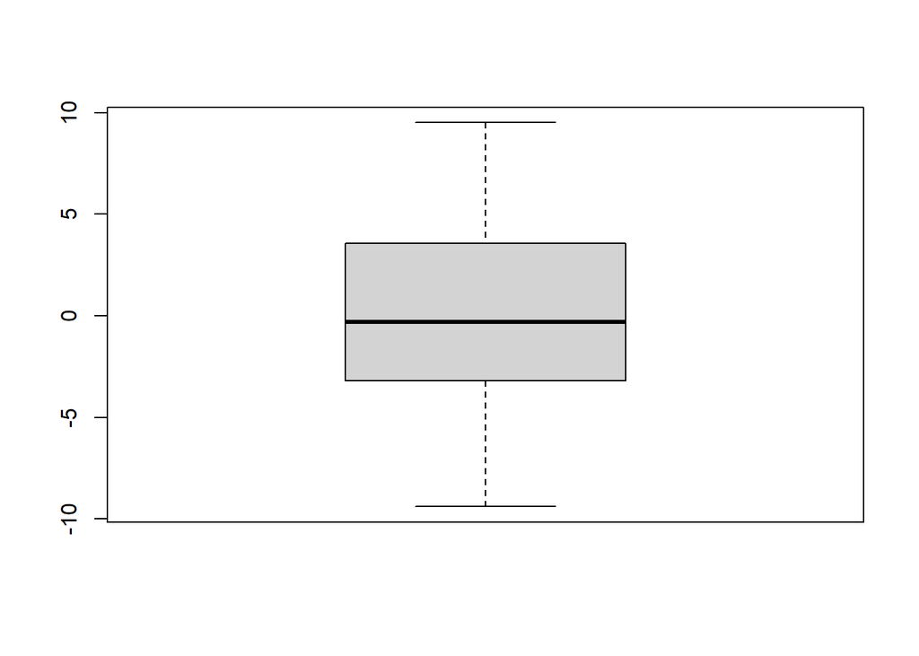

```r
## Graphs
boxplot(model1$residuals)
```

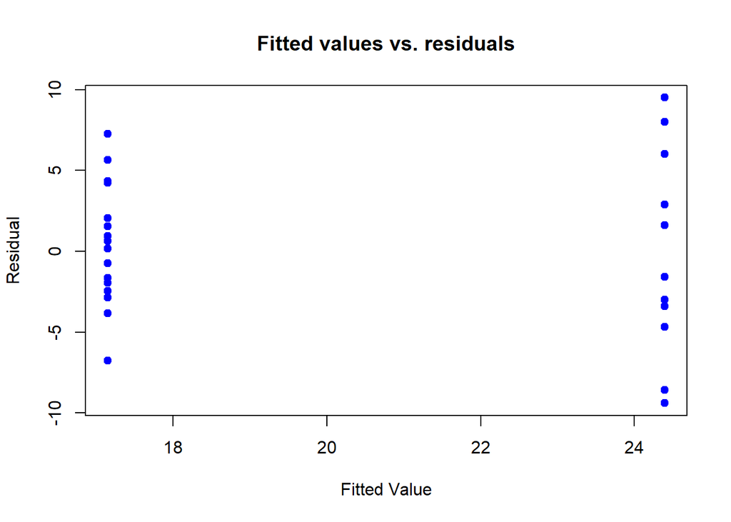

```r
plot(model1$fitted.values, model1$residuals, main = "Fitted values vs. residuals", xlab = "Fitted Value", ylab = "Residual", col = "blue", pch = 19)
```

```r
plot(model1$residuals, main = "Residuals of the fitted linear model", xlab = "Observation", ylab = "Residual", col = "blue", pch = 19)

## Hypotesis Testing:

# Normality
ad.test(model1$residuals)
```

```
##
##  Anderson-Darling normality test
##
## data:  model1$residuals
## A = 0.19947, p-value = 0.874
```

```r
# Heteroskedaticity
library("lmtest")
```

```r
bptest(model1)
```

```
##
##  studentized Breusch-Pagan test
##
## data:  model1
## BP = 5.0771, df = 1, p-value = 0.02424
```

```r
# Uncorrelation
dwtest(model1)
```

```
##
##  Durbin-Watson test
##
## data:  model1
## DW = 1.0647, p-value = 0.001446
## alternative hypothesis: true autocorrelation is greater than 0
```

From the graphs and hypotesis tests, we can conclude that the normality assumption is met, but the homoskedasticity and uncorrelated assumptions are violated. Therefore, the interpretation of the coefficients is not supported because the assumptions are not met. However, this model can be used only for description, as George Box said: *“All models are wrong, but some are useful”*

## Other Linear Models

Multiple regression models

```r
model_all <- lm(mpg ~ ., data = mtcars)
summary(model_all)
```

```
##
## Call:
## lm(formula = mpg ~ ., data = mtcars)
##
## Residuals:
##     Min      1Q  Median      3Q     Max
## -3.4506 -1.6044 -0.1196  1.2193  4.6271
##
## Coefficients:
##             Estimate Std. Error t value Pr(>|t|)
## (Intercept) 12.30337   18.71788   0.657   0.5181
## cyl         -0.11144    1.04502  -0.107   0.9161
## disp         0.01334    0.01786   0.747   0.4635
## hp          -0.02148    0.02177  -0.987   0.3350
## drat         0.78711    1.63537   0.481   0.6353
## wt          -3.71530    1.89441  -1.961   0.0633 .
## qsec         0.82104    0.73084   1.123   0.2739
## vs           0.31776    2.10451   0.151   0.8814
## am           2.52023    2.05665   1.225   0.2340
## gear         0.65541    1.49326   0.439   0.6652
## carb        -0.19942    0.82875  -0.241   0.8122
## ---
## Signif. codes:  0 '***' 0.001 '**' 0.01 '*' 0.05 '.' 0.1 ' ' 1
##
## Residual standard error: 2.65 on 21 degrees of freedom
## Multiple R-squared:  0.869,  Adjusted R-squared:  0.8066
## F-statistic: 13.93 on 10 and 21 DF,  p-value: 3.793e-07
```

```r
library(car)
vif(model_all)
```

```
##       cyl      disp        hp      drat        wt      qsec        vs        am
## 15.373833 21.620241  9.832037  3.374620 15.164887  7.527958  4.965873  4.648487
##      gear      carb
##  5.357452  7.908747
```

```r
model2 <- lm(mpg ~. - disp, data = mtcars)
vif(model2)
```

```
##       cyl        hp      drat        wt      qsec        vs        am      gear
## 14.284737  7.123361  3.329298  6.189050  6.914423  4.916053  4.645108  5.324402
##      carb
##  4.310597
```

```r
model3 <- lm(mpg ~. - disp - cyl, data = mtcars)
vif(model3)
```

```
##       hp     drat       wt     qsec       vs       am     gear     carb
## 6.015788 3.111501 6.051127 5.918682 4.270956 4.285815 4.690187 4.290468
```

```r
summary(model3)
```

```
##
## Call:
## lm(formula = mpg ~ . - disp - cyl, data = mtcars)
##
## Residuals:
##     Min      1Q  Median      3Q     Max
## -3.8187 -1.3903 -0.3045  1.2269  4.5183
##
## Coefficients:
##             Estimate Std. Error t value Pr(>|t|)
## (Intercept) 13.80810   12.88582   1.072   0.2950
## hp          -0.01225    0.01649  -0.743   0.4650
## drat         0.88894    1.52061   0.585   0.5645
## wt          -2.60968    1.15878  -2.252   0.0342 *
## qsec         0.63983    0.62752   1.020   0.3185
## vs           0.08786    1.88992   0.046   0.9633
## am           2.42418    1.91227   1.268   0.2176
## gear         0.69390    1.35294   0.513   0.6129
## carb        -0.61286    0.59109  -1.037   0.3106
## ---
## Signif. codes:  0 '***' 0.001 '**' 0.01 '*' 0.05 '.' 0.1 ' ' 1
##
## Residual standard error: 2.566 on 23 degrees of freedom
## Multiple R-squared:  0.8655, Adjusted R-squared:  0.8187
## F-statistic:  18.5 on 8 and 23 DF,  p-value: 2.627e-08
```